# STAT 6502 Annotated Class Notes

Daniel Park

2016-03-09

**January 04, 2016**

### Chapter 10: Data Summary

We now tackle the problem of estimating the behavior of a random variable where we have no (or very little) information about the population that the measurements came from.

Recall the population is uniquely defined by the cumulative distribution.

The cumulative distribution of $X$ evaluated at $x$ is $P(X \leq x)$.

In statistics, we assume that the sample well represents the population.

Functions of a random variable in a sample should be similar to that of the population (e.g. the sample mean to the population mean).

**Empirical Cumulative Distribution Function**
This is the estimator of the cdf, abbreviated as ecdf, and is defined as
$$F_n(x) = \frac{1}{n} \cdot (\text{number of} \ x_i\text{'s that are equal to or less than} \ x)$$
and has the properties

- let the ordered observations be $x_{(1)}, x_{(2)}, ... , x_{(n)}$. Then for $x < x_{(1)}, F_n(x) = \frac{1}{n}0= 0$.
- for $x_{(k)} \leq x < x_{(k+1)}, F_n(x)=\frac{k}{n}$.
- if there are $r$ observations with the value $x$, then $F_n(x)$ has a jump of $\frac{r}{n}$ at $x$.

We can show the ecdf is a consistent estimator of the cdf.

As $n$ approaches infinity, for fixed $\epsilon > 0$, Chebyshev’s inequality gives
$$\begin{aligned}
\lim_{n \to \infty} P\big(\big|F_n(x)-F(x) \big|<\epsilon\big) &= \lim_{n \to \infty} P\bigg(\bigg|\frac{Y}{n}-p\bigg| < \epsilon\bigg) \\
&\geq \lim_{n \to \infty} \bigg(1 - \frac{p(1-p)}{n\epsilon^2}\bigg) \\
&= 1
\end{aligned}$$

Therefore,
$$\lim_{n \to \infty} P\big(\big|F_n(x) - F(x)\big| < \epsilon \big) = 1$$

$\Big($ The derivation resulted in the inequality $\lim_{n \to \infty} P\big(\big|F_n(x) - F(x)\big| < \epsilon \big) \geq 1$. However, since probabilities cannot exceed 1, the inequality becomes $\lim_{n \to \infty} P\big(\big|F_n(x) - F(x)\big| < \epsilon \big) = 1$.$\Big)$

Since $F_n(x) = \hat{p}$ is the proportion of times that $X \leq x$, we may rely on the Weak Law of Large Numbers (WLLN), which states that $F_n(x)$ will converge in probability to $F(x)=p$, or $F_n(x) \xrightarrow{p} F(x)$.

Reminder: $\xrightarrow{p}$ means that it converges in probability.

In fact, the consistency of $F_n$ holds uniformly over the real line
$$\sup_{- \infty < x < \infty} \big|F_n(x) - F(x) \big| \xrightarrow{p} 0$$

Demonstration in R:

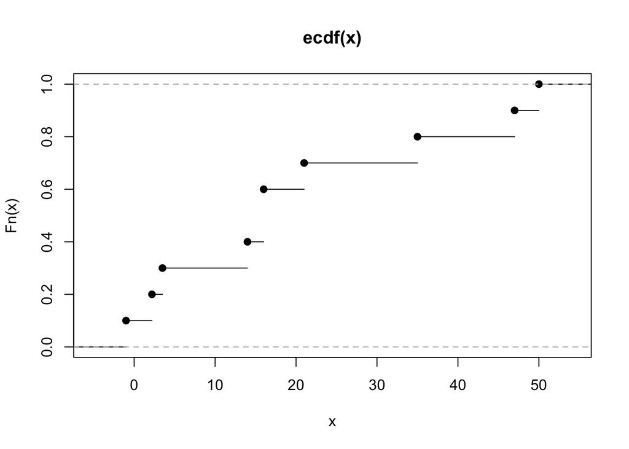

```r
# randomly selecting numbers, intentionally including two 16s:
x <- c(16, 16, 14, 3.5, -1, 2.2, 35, 47, 50, 21)
plot(ecdf(x))
```

```r
# Repeat, but this time randomly generate the numbers.
# We generate 30 observations, each with 20 trials.
# The expected value of each observation is 6; that is, with a probability
#   of 0.3, we expect 6 successes from 20 trials.
y <- rbinom(n=30, size=20, prob=.3)
y
```

```
##  [1] 10  4  2  8  7 11  8  5  5  5  6  8  5  4  8  4  7  6  8  4  5  5  6
## [24]  6  7  4  6  6  8  4
```

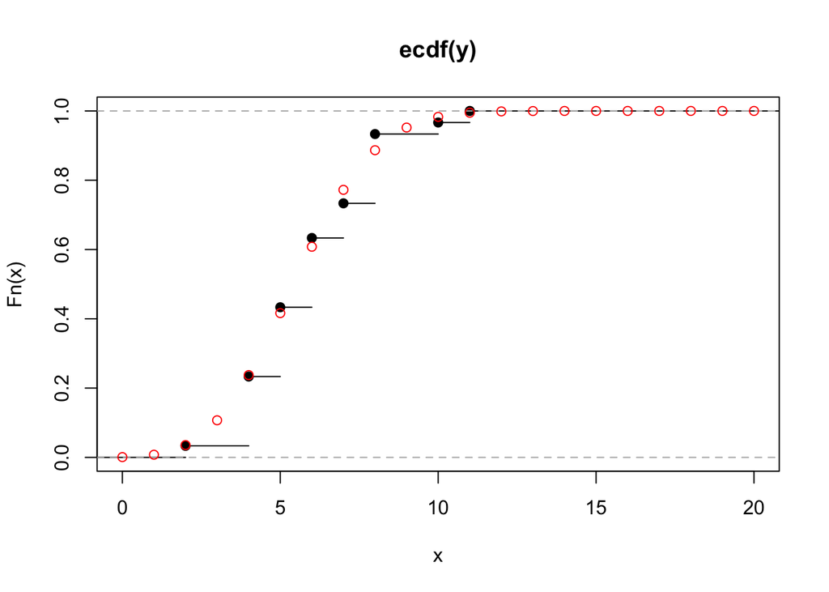

```r
plot(ecdf(y), xlim=c(0,20))

# actual distribution:
points(x=0:20, y=pbinom(q=0:20, size=20, prob=.3), col='red')
```

```r
#lines(x=0:20, y=pbinom(q=0:20, size=20, prob=.3), col='red')
```

For mathematical purposes, it is convenient to express $F_n$ as
$$F_n(x) = \frac{1}{n} \sum_{i=1}^n \textbf{I}_{(-\infty, x]}(X_i)$$
where $\textbf{I}$ is the usual indicator function.
$$\textbf{I}_{(-\infty, x]}(X_i)=\begin{cases}
1, \text{if} \ X_i \leq x \\
0, \text{if} \ X_i > x
\end{cases}$$

Writing it in this way, we see that $\textbf{I}_{(-\infty, x]}(X_i)$ is a Bernoulli random variable with
$$P(\textbf{I}_{(-\infty, x]}(X_i) = 1) = F(x)$$
$$\text{and}$$
$$P(\textbf{I}_{(-\infty, x]}(X_i) = 0) = 1 - F(x)$$

As an estimator, the ecdf is not only consistent, it is unbiased, and its variance gets smaller the further $x$ is from the median.

**January 06, 2016**

**Mean and Variance**
Problem: Show that the ecdf is unbiased for the cdf.
$$\begin{aligned}
E(F_n) &= E\bigg[\frac{1}{n} \sum_{i=1}^n \textbf{I}_{(-\infty,x]}(X_i)\bigg] \\
&= \frac{1}{n}nE[\textbf{I}_{(-\infty,x]}(X_i)] \\
&= P(X_i \leq x) \\
&= F(x)
\end{aligned}$$
For the variance, note that since $\textbf{I}_{(-\infty,x]}(X_i)$ can only take values 0 or 1, $E[(\textbf{I}_{(-\infty,x]}(X_i))^2] = E[\textbf{I}_{(-\infty,x]}(X_i)]$ which is equal to $P(X_i \leq x)$.

Therefore,
$$\begin{aligned}
\text{Var}(F_n(x)) &= E[F^2_n(x)]-[E(F_n(x))]^2 \\
&= E\bigg[\frac{1}{n^2} \sum_{i=1}^n \textbf{I}_{(-\infty,x]}(X_i) \sum_{j=1}^n \textbf{I}_{(-\infty, x]}(X_j)\bigg]-F^2(x) \\
&= \frac{1}{n^2} \sum_{i=1}^n \sum_{j=1}^n[P(X_i \leq x, X_j \leq x)-F^2(x)] \\
&= \frac{1}{n^2} \sum_{i=1}^n F(x)(1-F(x))+ \frac{1}{n^2} \sum_{i \neq j}[F_{X_iX_j}(x,x)-F^2(x)]
\end{aligned}$$
If they are independent, then
$$F_{X_iX_j}(x,x)=F^2(x)$$
which means that
$$\sum_{i \neq j}[F_{X_iX_j}(x,x)-F^2(x)] = 0$$
So,
$$\begin{aligned}
\text{Var}(F_n(x)) &= \frac{1}{n^2} \sum_{i=1}^n F(x)(1-F(x)) \\
&= \frac{1}{n} F(x)(1-F(x))
\end{aligned}$$

It is clear that the variance hits its maximum when $F(x)=0.5$, otherwise known as the median.

Also, $\text{Var}(F_n(x))$ gets smaller as you go away from the median.

A drawback is that the ecdf is always a step-function, whereas the cdf of a continuous distribution is not, so we may lose out on important features.

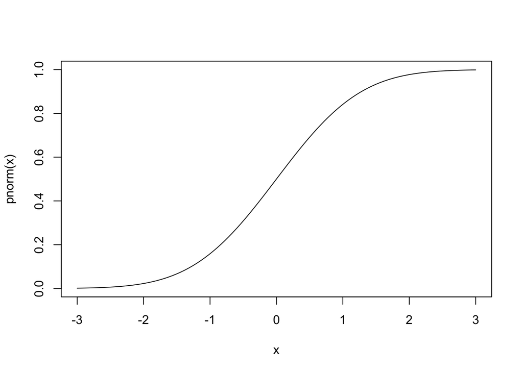

```r
curve(pnorm, -3, 3) # cdf of normal dist
```

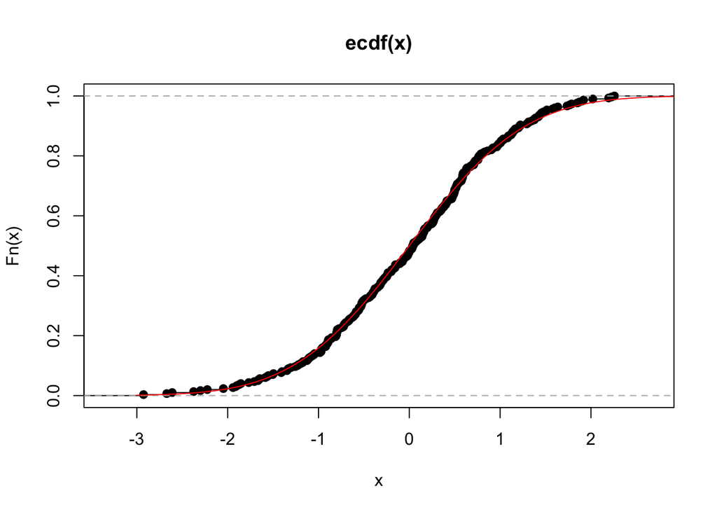

```r
x <- rnorm(300) # 300 observations
plot(ecdf(x))
curve(pnorm, -3,3,add=TRUE,col='red') # true cdf
```

The plotted ecdf are steps. Note that typically the true cdf is unknown (which is why we’re interested in the estimator ecdf).

As an estimator, the ecdf can be used to estimate many functional parameters of $F$.

**Example**
Suppose that
$$\theta(F)=\int_{-\infty}^{\infty} h(x)dF(x)$$
which is essentially $E[h(x)]$.

Substituting $F_n$ for $F$, we get
$$\begin{aligned}
\hat{\theta} &= \theta(F_n) \\
&= \int^{\infty}_{-\infty} h(x)dF_n(x) \\
&= \frac{1}{n} \sum_{i=1}^n h(x_i)
\end{aligned}$$
which is simply the sample mean of $h(x_1), h(x_2),...,h(x_n)$.

Here, $\theta=\theta(F)$ is the true value of the parameter, and $\hat{\theta}=\theta(F_n)$ is its estimator.

**Example**
Suppose that $\theta(F)=\text{Var}(X)$ where $X \sim F$.
$$\theta(F)=\int^{\infty}_{-\infty} x^2 dF(x)-\bigg(\int_{-\infty}^{\infty}xdF(x)\bigg)^2$$
and we get
$$\begin{aligned}
\hat{\theta} &= \theta(F_n) \\
&= \frac{1}{n}\sum_{i=1}^n x_i^2-\bigg(\frac{1}{n}\sum_{i=1}^n x_i\bigg)^2 \\
&= \frac{1}{n} \sum_{i=1}^n \big(x_i-\overline{X}\big)^2
\end{aligned}$$

**Survival**
The survival function is defined as
$$S(t)=P(T>t)=1-F(t)$$
where $T$ is a random variable with cdf $F$.

This is commonly found in biostatistics and reliability theory as $S(t)$ represents the probability that the lifetime will be longer than $t$.

From our prevous discurssion, the intuitive estimator of the survival function is
$$S_n(t)=1-F_n(t)$$
which is consistent and unbiased, the proportion of the data greater than $t$.

A survival function can be used to calculate the hazard function, which may be interpreted as the instantaneous death rate for individuals who have suvived up to a given time.

For small $\delta$, we calculate the probability that the individual will die in the time interval $(t,t+\delta)$
$$\begin{aligned}
P(t\leq T \leq t + \delta | T>t) &= \frac{P(t \leq T \leq t+\delta)}{P(T>t)} \\
&= \frac{F(t+\delta)-F(t)}{1-F(t)} \\
&\approx \frac{\delta f(t)}{1-F(t)}
\end{aligned}$$
The hazard rate function is defined as $h(t)=\frac{f(t)}{1-F(t)}$ and alternatively expressed as
$$h(t)=-\frac{d}{dt}\log(1-F(t)) = -\frac{d}{dt}\log(s(t))$$

**Example**  
In R, plot the hazard rate function for the Weibull with $\alpha=1$ and $\beta=0.8,1.0,1.5$

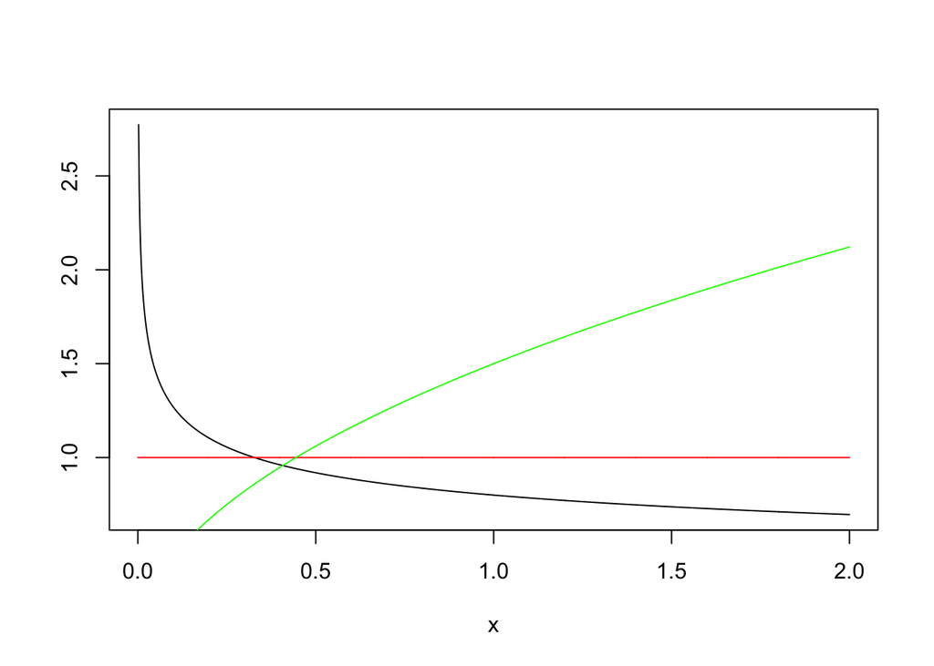

```r
x <- seq(0,2,length=1000)
plot(x,dweibull(x,0.8,1)/(1-pweibull(x,0.8,1)), type='l',ylab='')
lines(x,dweibull(x,1,1)/(1-pweibull(x,1,1)),col='red')
lines(x,dweibull(x,1.5,1)/(1-pweibull(x,1.5,1)),col='green')
```

**Problem**
Find the hazard rate function for exponentially distributed lifetimes. What does this tell you?
$$\begin{aligned}
h(t) &= \frac{f(t)}{1-F(t)} \\
&= \frac{\lambda e^{-\lambda t}}{1-(1-e^{-\lambda t})} \\
&= \lambda
\end{aligned}$$

**Density Estimation**  
The glaring issue with using the ecdf as an estimator of $F$ arises when $F$ is continuous (since the ecdf is always a step function).

In this situation, one way of deriving a smoothed estimate is using the kernel probability density estimate.

The idea is to use $w(x)$, where this function is a nonnegative, symmetric weight function, centered at zero and integrates to 1 (pdf).

**January 11, 2015**  
This $w$ uses the $X_i$ to come up with a smoothed estimate at $x$.

However, we may not want to use values of $X_i$ that are too far from $X_j$ since those values won’t tell us much about the distribution at $x$.

Even for those values not too far away from $x$, we would want to weight values closest to $x$ more than those that are further away.

Therefore, we need to decide on a bandwidth, $h$, and run this smoother in this bandwidth around $x$, on the known support $X$.

The choice of $h$ can have a profound effect on the quality of the density estimate.

The choice of $h$ is problem specific.

We can write this weight function as
$$W_h(x) = \frac{1}{h}w\bigg(\frac{x}{h}\bigg)$$
giving our estimate of $f$,
$$\begin{aligned}
f_h(x) &= \frac{1}{n}\sum_{i=1}^n W_h(x-X_i) \\
&= \frac{1}{nh}\sum_{i=1}^n w\bigg(\frac{x-X_i}{h}\bigg)
\end{aligned}$$
If $h$ is too small we will have undersmoothing, producing a rough $f$, not much different than the unsmoothed.

If $h$ is too large, then we will have oversmoothing, possibly losing out on some features of the true $f$.

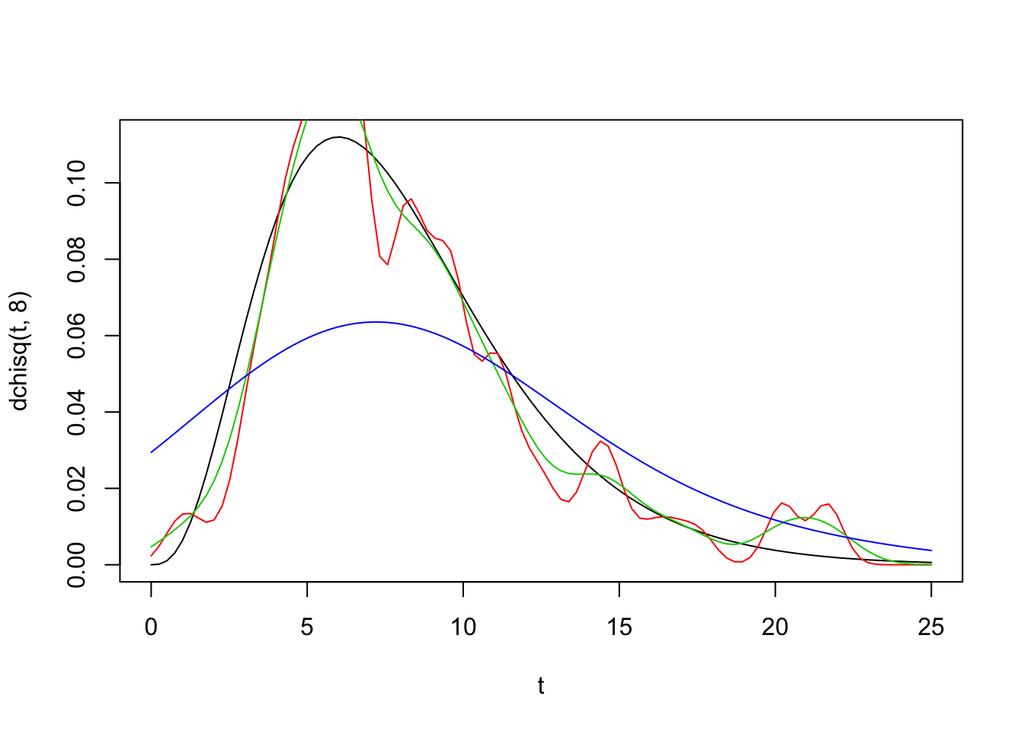

```r
n <- 100
x <- rchisq(n,8)
#h <- 1
h <- c(0.5, 1, 5)
t <- seq(0,25, length=n)
fhat1 <- matrix(0, nrow=n, ncol=length(h))

plot(t, dchisq(t,8), type='l')

for (j in 1:length(h)){
  for (i in 1:n){
        fhat1[i,j] = 1/(n*h[j])*sum(dnorm((t[i]-x)/h[j]))
        }
    lines(t, fhat1[,j], xlab='x', ylab='', col=j+1)
    }
```

Alternatively, we could use the `KernSmooth` library to accomplish the same thing.

```r
# Alternatively

plot(density(x))

# or

library(KernSmooth)

fhat3 <- bkde(x)
plot(fhat3, xlab='x', ylab='',type='l')
lines(t, dchisq(t,8), col='red')
```

[output not shown]